# 2213453

ZEESHAN FIRDOUSI

2023-04-12

## Exploratory Data Analysis of CPE’s Dallas Policing Dataset of 2016

### INTRODUCTION

#### The data provided includes information regarding crime incidences that happened in Dallas, Texas, the United States, as well as data about the officer, subject, place, race, date, time, method of force used, and other metrics for the entire 2016 year.

#### The Centre for Policing Equity (CPE) generated a data set that focuses on policing in Dallas, Texas in 2016. This report’s goal is to study that data set. The goal of the CPE is to use cutting-edge analysts to make policing diagnoses that shed light on police behaviour and offer meaningful advice to police forces.This set of data includes 2384 incidents and information on 47 factors.The data pertains to 2016, which runs from January through December.This research breaks down and explores patterns in policing behaviour using significant data visualisation.

```r
#Loaded the libraries
library(tidyverse)
library(kableExtra)
library(gmodels)
library(gridExtra)
library(grid)
library(scales)
library(lubridate)
library(xts)
library(maps)
library(rgdal)
library(ggplot2)
library(Rcpp)
library(sf)
library(tidyverse)
library(ggmap)
library(ggthemes)
library(viridis)
library(hrbrthemes)
library(forcats)
library(ggridges)
library(plotly)
library(rnaturalearth)
library(rnaturalearthdata)
library(corrplot)
library(ggcorrplot)
library(ggpubr)
library(ggforce)
library(lubridate)
library(furniture)
library(patchwork)
```

#### “Data visualization is the language of decision making. Good charts effectively convey information. Great charts enable, inform, and improve decision making.” — Dante Vitagliano

#### In accordance to the quote, visualisation makes things easier for individuals to understand as compared to those that are conveyed conceptually.To make things more straightforward, we are going to demonstrate how the given relate to one another.

### Data Analysis

#### Installing the libraries required to plot the data in an interactive and understandable manner needs to be done before we can begin our exploratory data analysis. There are a few representations that cannot be made due to null values in the provided data set. As a result, rather than making plots, we create tables.

```r
#Setting the Working Directory to Start the Working with file
setwd("E:/MA304")
getwd()
```

```
## [1] "E:/MA304"
```

```r
#Reading the dataset
dallas<-read.csv("37-00049_UOF-P_2016_prepped.csv")

#In the below line of code we are to remove the 1 row which is having some random and null values,So we cannot consider those values.
dallas<-dallas[-1,]
```

```r
#Date and Month Conversion:
dallas$INCIDENT_DATE <- as.Date(dallas$INCIDENT_DATE, format = "%m/%d/%Y")
dallas$INCIDENT_DATE <- gsub("00","20",dallas$INCIDENT_DATE)
dallas$INCIDENT_DATE <- as.Date(dallas$INCIDENT_DATE, format = "%Y-%m-%d")
dallas$INCIDENT_TIME <- format(strptime(dallas$INCIDENT_TIME, "%I:%M:%S %p"), "%H:%M:%S")
dallas$INCIDENT_MONTH <- months(as.Date(dallas$INCIDENT_DATE))
dallas$INCI_MONTH <-format(dallas$INCIDENT_DATE,"%m")
```

### Subject Race Vs Incident Month

#### The plot of bars between the frequency of occurrences each month and the subject’s ethnicity is the one I’d want to show you at this point. I’d like to first exhibit a table, secondly a bar plot, to make it more visually appealing and understandable.

#### The graph depicts the change of engagement rates for each Subject Race. It can be observed that out of all the months, March(03) saw the highest number of incidents related to a certain race.

```r
#Bar Plot Has been plotted between Subject Race and Inci Month


counts <- table(factor(dallas$SUBJECT_RACE,level=c("American Ind","Asian","Black","Hispanic","Other","White")),dallas$INCI_MONTH)
counts
```

```
##
##                 01  02  03  04  05  06  07  08  09  10  11  12
##   American Ind   0   0   0   1   0   0   0   0   0   0   0   0
##   Asian          1   0   0   1   0   1   0   0   0   2   0   0
##   Black        111 150 162 116 139 116  94  92 121  88  84  60
##   Hispanic      75  52  67  54  37  37  41  46  39  29  28  19
##   Other          0   0   2   0   1   1   0   4   2   1   0   0
##   White         43  47  30  50  41  31  38  47  42  49  34  18
```

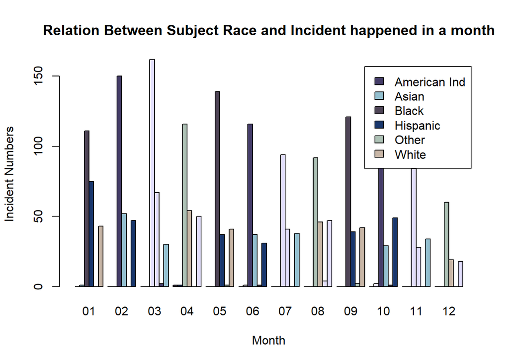

```r
barplot(counts,main = "Relation Between Subject Race and Incident happened in a month",xlab ="Month",ylab="Incident Numbers",col =c("#443C68","#93BFCF","#4F4557","#19376D","#AEC2B6","#C8B6A6","#E3DFFD","#E3DFFD"), legend=rownames(counts),beside=TRUE)
```

### Year of Experience of Officer on Force

#### The frequency of officers by number of years on the force can be seen in the histogram figure below. We notice that the majority of the officers have one to ten years of experience, with a substantial drop after ten years.

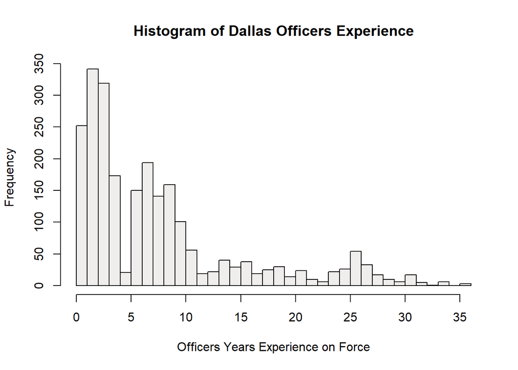

```r
dallas$OFFICER_YEARS_ON_FORCE1 <- as.numeric(dallas$OFFICER_YEARS_ON_FORCE)
hist(dallas$OFFICER_YEARS_ON_FORCE1,breaks=50,col = "#F0EEED",xlab="Officers Years Experience on Force",main = "Histogram of Dallas Officers Experience")
```

### Subject Description VS Subject Race

#### The barplot that follows shows the subjects’ ethnicity and demographic characteristics. We can see that Black people, who constitute the majority of the population as a whole, likely to be mentally ill.In addition, we can see that subjects of other races engage in various forms of Description.

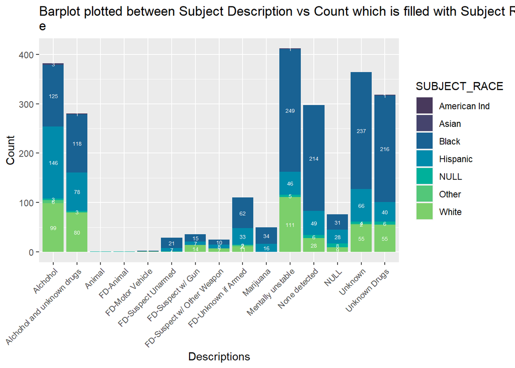

```r
ggplot(dallas,aes(x=SUBJECT_DESCRIPTION,fill=SUBJECT_RACE))+geom_bar(stat ="count")+theme(axis.text.x = element_text(angle = 45, size=8 ,hjust = 1))+stat_count(geom = "text", colour = "white", size = 1.8,aes(label =..count..),position=position_stack(vjust=0.5))+labs(x="Descriptions",y="Count",title = "Barplot plotted between Subject Description vs Count which is filled with Subject Rac
e")+scale_fill_manual(values = c( "#48395c", "#45446d", "#196293", "#008bab", "#00b09a", "#53c779", "#7ccf6b"))
```

### Relation Shown of Subject Race and Officer Race with Months

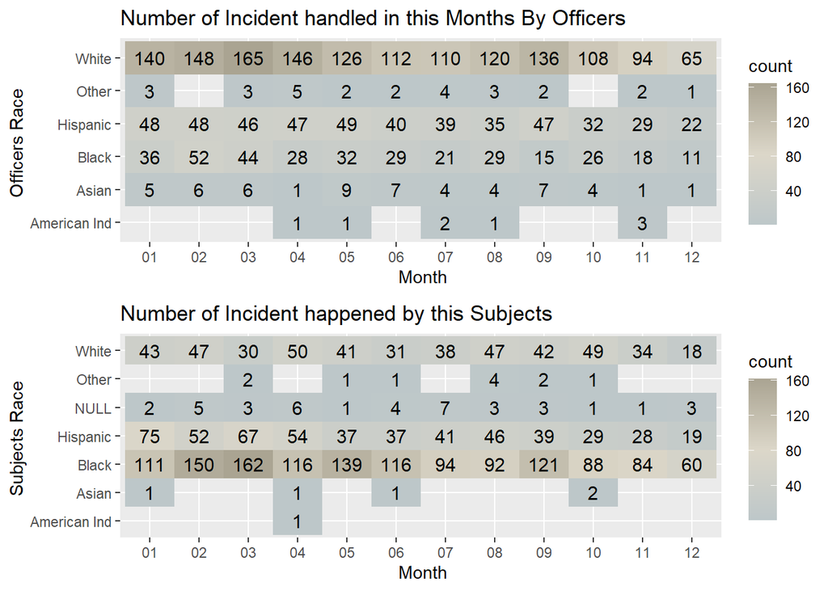

```r
options(dplyr.summarise.inform = FALSE)

dallasSubjectRace <-  dallas %>%
  group_by(SUBJECT_RACE, INCI_MONTH) %>%
   dplyr::summarize(count = n())

dallasOfficerRace <-  dallas %>%
  group_by(OFFICER_RACE, INCI_MONTH) %>%
   dplyr::summarize(count = n())

dallasSubjectRace <- dallasSubjectRace[complete.cases(dallasSubjectRace), ]
dallasOfficerRace <- dallasOfficerRace[complete.cases(dallasOfficerRace), ]

g1 <- ggplot(dallasOfficerRace, aes(x= INCI_MONTH, y=OFFICER_RACE,fill= count)) + geom_tile()+
  geom_text(aes(INCI_MONTH, OFFICER_RACE, label = count), color = "black", size = 4) + labs(x=" Month", y= "Officers Race ")+
  scale_fill_gradientn(colours = c("#BDC7C9", "#DCD7C9", "#AAA492"))+ggtitle("Number of Incident handled in this Months By Officers")

g2 <- ggplot(dallasSubjectRace, aes(x= INCI_MONTH, y=SUBJECT_RACE,fill = count)) + geom_tile() +
  geom_text(aes(INCI_MONTH, SUBJECT_RACE, label = count), color = "black", size = 4) + labs(x=" Month", y= "Subjects Race ")+
  scale_fill_gradientn(colours = c("#BDC7C9", "#DCD7C9", "#AAA492"))+ggtitle("Number of Incident happened by this Subjects")

grid.arrange(g1,g2, nrow=2,ncol=1)
```

### Force Applied: Type

### Relationship between Subject Race and the Force Used

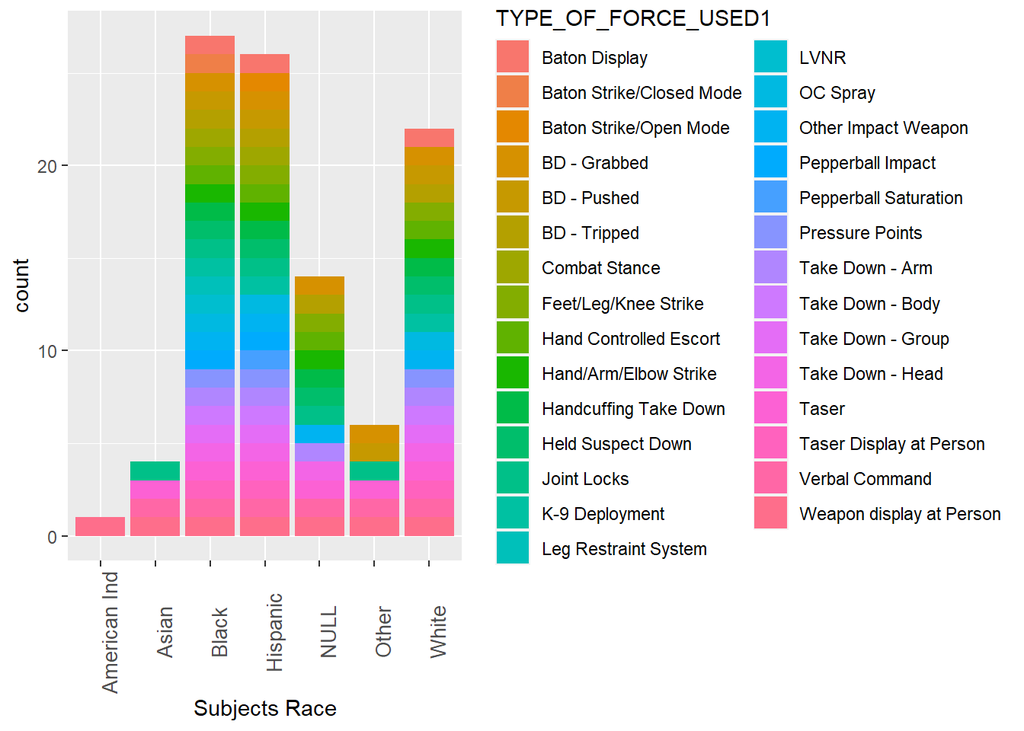

```r
#How many incident happened in a month because of the Subject Description
dallastrace <- dallas %>%
  group_by(SUBJECT_RACE,TYPE_OF_FORCE_USED1) %>%
   dplyr::summarize(count = n())

 ggplot(dallastrace,aes(x = SUBJECT_RACE,fill=TYPE_OF_FORCE_USED1))+geom_bar()+labs(x="Subjects Race")+theme(axis.text.x = element_text(angle = 90, size = 10))
```

### Subject Gender VS Type of Force Used

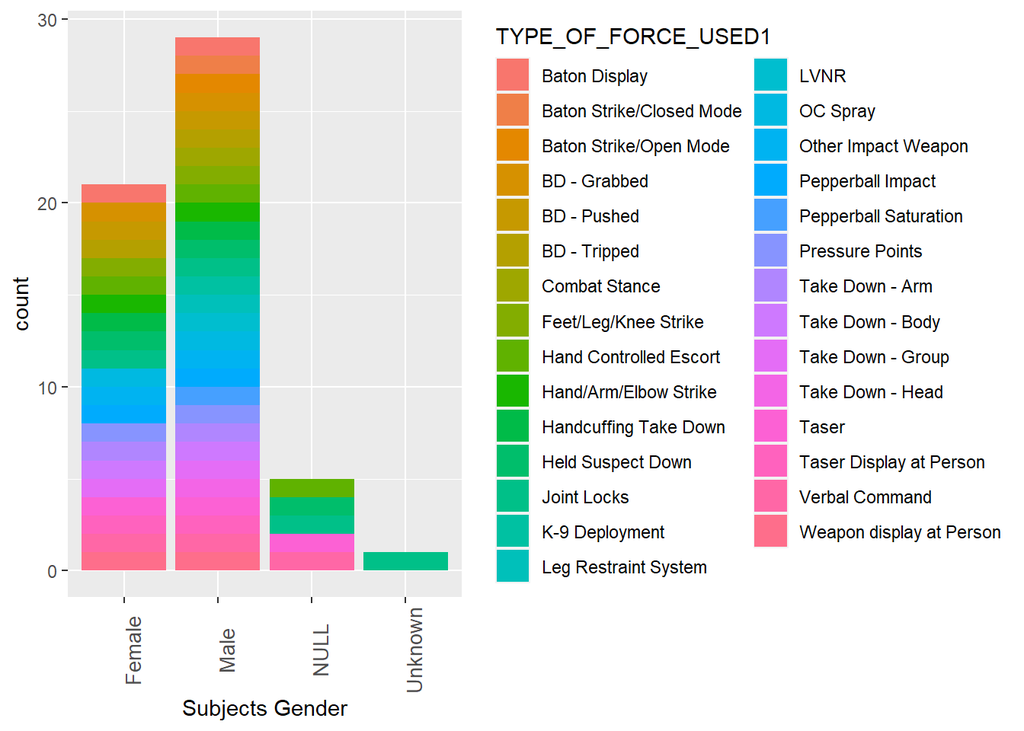

```r
dallasTgend <- dallas %>%
  group_by(SUBJECT_GENDER,TYPE_OF_FORCE_USED1) %>%
   dplyr::summarize(count = n())

ggplot(dallasTgend,aes(x = SUBJECT_GENDER,fill=TYPE_OF_FORCE_USED1))+geom_bar()+labs(x="Subjects Gender")+theme(axis.text.x = element_text(angle = 90, size = 10))
```

### Analysis of Incidents Months and Subject Description

#### The subject description is broken down in months and the number of descriptions in the plot below. Except for one, the plot show includes 14 descriptions. As a whole, Mentally Unstable has the highest count for the entire year.

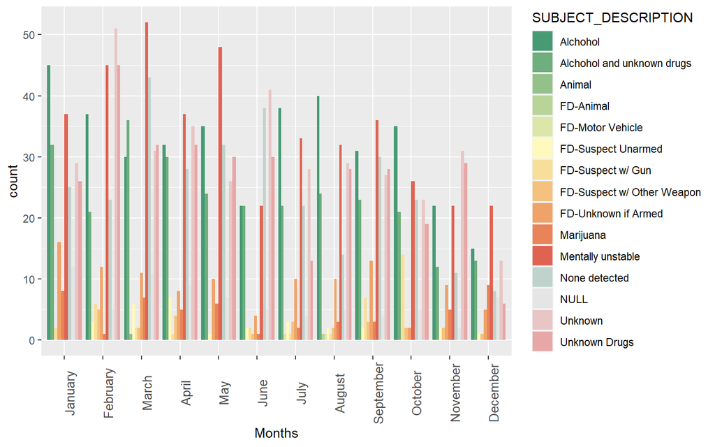

```r
#
ggplot(dallas,aes(x = factor(INCIDENT_MONTH,level=c('January', 'February', 'March', 'April',
'May', 'June', 'July', 'August', 'September', 'October', 'November','December')),fill=SUBJECT_DESCRIPTION))+geom_bar(position = "dodge")+labs(x="Months")+theme(axis.text.x = element_text
(angle = 90, size = 10))+scale_fill_manual(values = c("#469a74","#6fae7d","#94c189","#b8d498","#dce6a9","#fff9bd","#f8de9b","#f4c17e","#efa368","#e98459","#e06352","#c0d2cc","#e5e5e5","#e8c6c5","#e7a7a7"))
```

### The relationship between Division and Subject Race is depicted by a bar graph.

#### From below bar plot we can observe that most of the people who belong to Black enthicty are from Central Division followed by South Central Division.Which depicts that most of the Black Enthicity were engaged in most incidents.

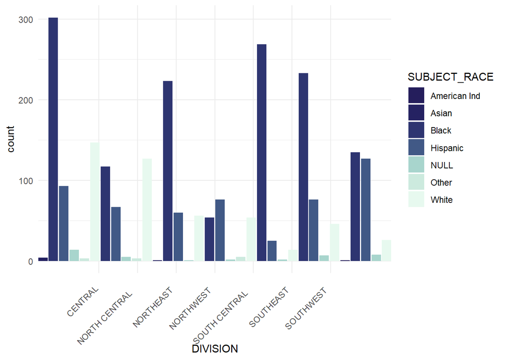

```r
#Making
dallasDivvsSubRace<- dallas %>%
 group_by(DIVISION,SUBJECT_RACE) %>%
 dplyr::summarize(count = n())
ggplot(dallasDivvsSubRace, aes(x= DIVISION, y=count,fill=SUBJECT_RACE)) +geom_bar(stat = "identity",width = 1.62,position=position_dodge2(preserve = "single"))+theme_minimal()+theme(axis.text.x = element_text(angle = 45,hjust = 1.2))+scale_fill_manual(values=c("#251e5c", "#252262", "#2e3571", "#415986","#a8d5cd", "#cceade", "#e7f9ef"))
```

### Incorporating Incident Cause and Officer Race vs. Officer Numbers

#### The instances in the graph at the top are those in which the cops were involved.As can be observed, the most frequent incident reason was to make an arrest, and the second most frequent reason was to conduct a service call.

. White police are more likely to record incidents, even though this is not surprising given that the plot reveals that white officers make up the large majority of the force.

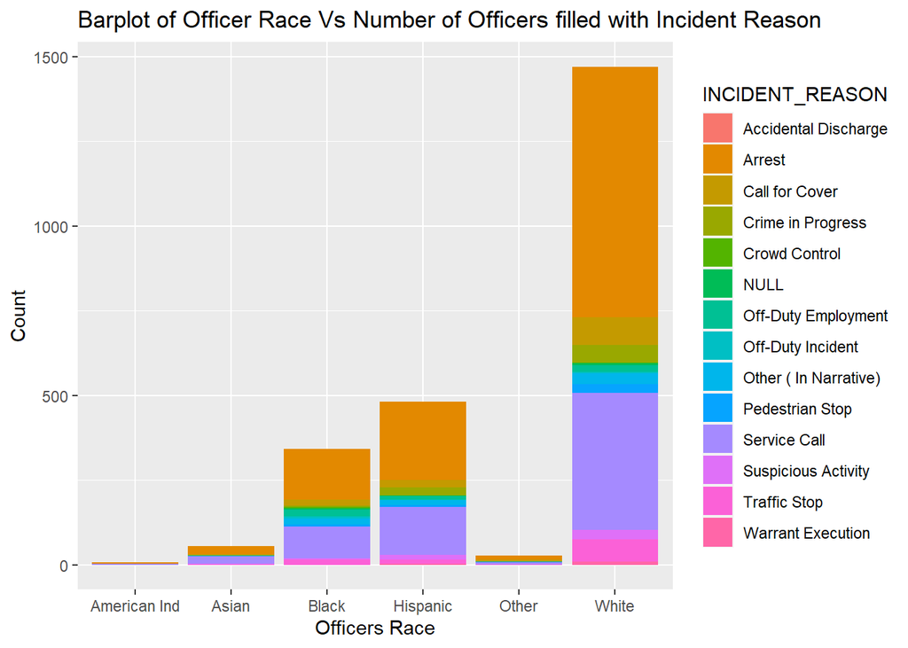

```r
dallasOffiVsIncideReason <- dallas %>%
  group_by(OFFICER_RACE,INCIDENT_REASON) %>%
   dplyr::summarize(count=n())


ggplot(dallasOffiVsIncideReason, aes(x=OFFICER_RACE,y=count,fill=INCIDENT_REASON)) +
  geom_bar(stat = "identity")+labs(x="Officers Race",y="Count",title = "Barplot of Officer Race Vs Number of Officers filled with Incident Reason")
```

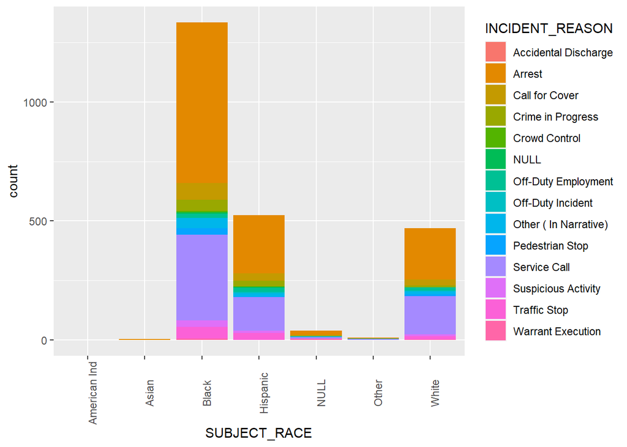

```r
#Making a new dataframe in which we are combing the columns so that we can plot a graph against that.
dallasSubVsIncideReason <- dallas %>%
  group_by(SUBJECT_RACE,INCIDENT_REASON) %>%
   dplyr::summarize(count=n())

#
ggplot(dallasSubVsIncideReason, aes(x=SUBJECT_RACE,y=count,fill=INCIDENT_REASON)) +
  geom_bar(stat = "identity")+theme(axis.text.x = element_text(angle = 90))
```

### Density plot of location districts and subject description

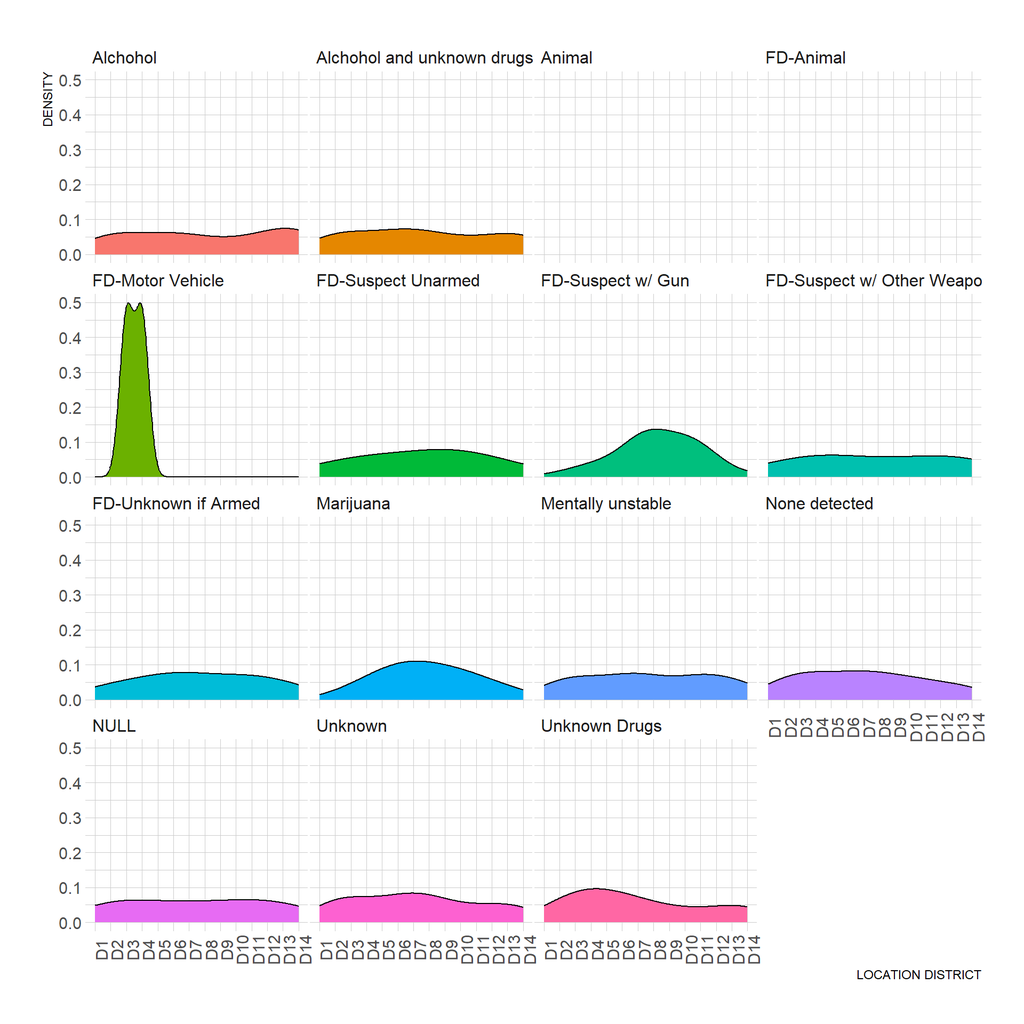

```r
#District Location relation shown with Subject Description, So that we can the number of Descriptions happening in months

ggplot(dallas,aes(factor(LOCATION_DISTRICT,level=c('D1','D2','D3','D4','D5','D6','D7','D8','D9','D10','D11','D12','D13','D14')),group=SUBJECT_DESCRIPTION,fill=SUBJECT_DESCRIPTION)) +
    geom_density(adjust=1.5) +
    theme_ipsum() +
    facet_wrap(~SUBJECT_DESCRIPTION) +
    theme(
      legend.position="none",
      panel.spacing = unit(0.1, "lines"),
      axis.ticks.x=element_blank(),
      axis.text.x = element_text(angle = 90)
    )+
    xlab("LOCATION DISTRICT") +ylab("DENSITY")
```

### Incident Months of Subjects Injury VS Officer Injury

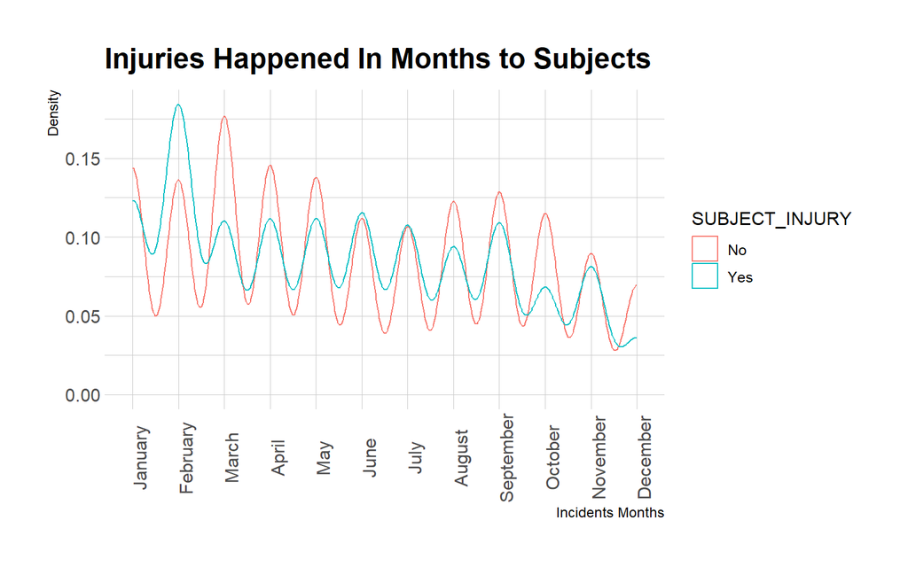

```r
#Density Plot
ggplot(dallas, aes(x=factor(INCIDENT_MONTH,level=c('January', 'February', 'March', 'April', 'May', 'June', 'July', 'August', 'September', 'October', 'November','December')), group=SUBJECT_INJURY,color=SUBJECT_INJURY,fill=INCIDENT_MONTH)) +
    geom_density(alpha=0.4,adjust=2/5) +
    theme_ipsum()+theme(axis.text.x = element_text(angle = 90))+
ggtitle("Injuries Happened In Months to Subjects")+labs(x="Incidents Months",y="Density")
```

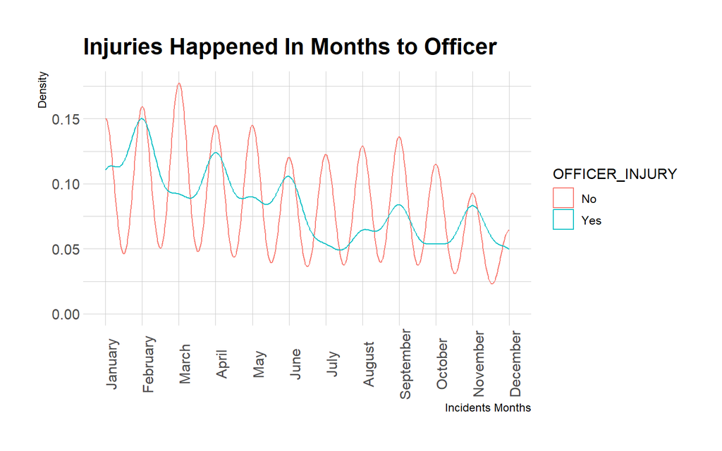

```r
#Density plot .
ggplot(dallas, aes(x=factor(INCIDENT_MONTH,level=c('January', 'February', 'March', 'April', 'May', 'June', 'July', 'August', 'September', 'October', 'November','December')), group=OFFICER_INJURY,color=OFFICER_INJURY,fill=INCIDENT_MONTH)) +
    geom_density(alpha=0.4,adjust=2/5) +
    theme_ipsum()+theme(axis.text.x = element_text(angle = 90))+
ggtitle("Injuries Happened In Months to Officer")+labs(x="Incidents Months",y="Density")
```

### Subjects Injury VS Subject Race.

#### The relationship between Subject Race and Subject Injuries has been established.We can therefore infer from the plot that Black and Hispanic ethnicities suffered serious harm.And we can observe from the above plot shown above that the bulk of the subjects suffered injuries in a specific time frame.

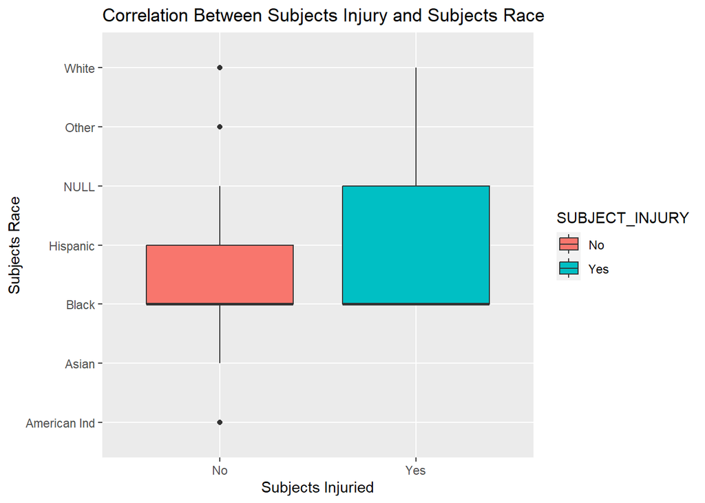

```r
ggplot(dallas, aes(SUBJECT_INJURY, SUBJECT_RACE, fill=SUBJECT_INJURY,group=SUBJECT_INJURY)) +
    geom_boxplot()+labs(x="Subjects Injuried",y="Subjects Race",title = "Correlation Between Subjects Injury and Subjects Race")
```

### Subjects Race VS Location District.

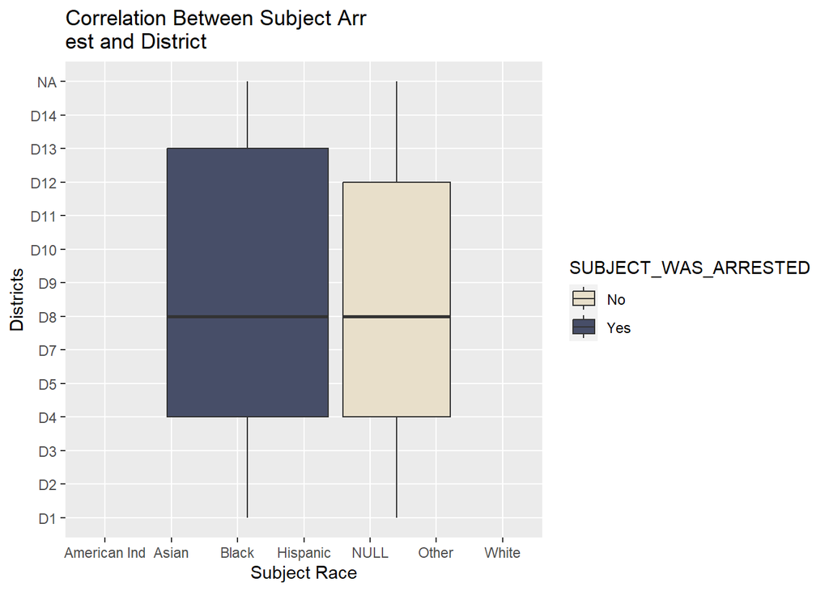

```r
#The below code is written to plot a graph between SUbject Arrested or not in that District Location. So we can Find that how many people have been arrested from the particular district.
ggplot(dallas, aes(SUBJECT_RACE,factor(LOCATION_DISTRICT,level=c('D1','D2','D3','D4','D5','D
6','D7','D8','D9','D10','D11','D12','D13','D14')),fill=SUBJECT_WAS_ARRESTED,group=SUBJECT_WAS_ARRESTED))+
 geom_boxplot()+labs(x="Subject Race",y="Districts",title = "Correlation Between Subject Arr
est and District")+scale_fill_manual(values = c("#E8DFCA","#474E68"))
```

### Location District vs Incident date BoxPlot

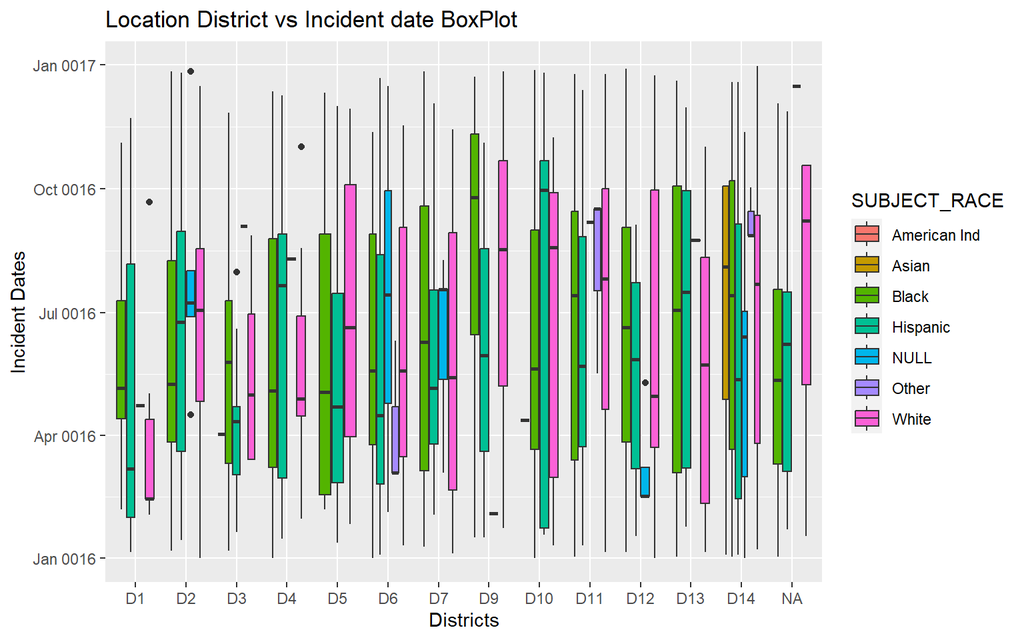

```r
ggplot(dallas, aes(factor(LOCATION_DISTRICT,level=c('D1','D2','D3','D4','D5','D6','D7','D
8','D9','D10','D11','D12','D13','D14')),INCIDENT_DATE,fill=SUBJECT_RACE))+ geom_boxplot()+labs(x="Districts",y="Incident Dates",title = "Location District vs Incident date BoxPlot")
```

### Map

#### Map shows the location of districts which can be more easier to identify.

```r
library(leaflet)

map <- dallas[sample(nrow(dallas),30),]

map$LOCATION_LATITUDE <- as.numeric(map$LOCATION_LATITUDE)
map$LOCATION_LONGITUDE <- as.numeric(map$LOCATION_LONGITUDE)

m <- leaflet(map)%>%
  addTiles()

 m %>% addMarkers(lng = ~map$LOCATION_LONGITUDE,lat = ~map$LOCATION_LATITUDE,popup = ~paste("DISTRICT NUMBER: *",LOCATION_DISTRICT))
```

[interactive chart not shown]

### Scatter Plot of Subject Race and Subject Arrest

#### The majority of the detentions consisted of Black and Hispanic people, and the majority of these individuals were male before the female.

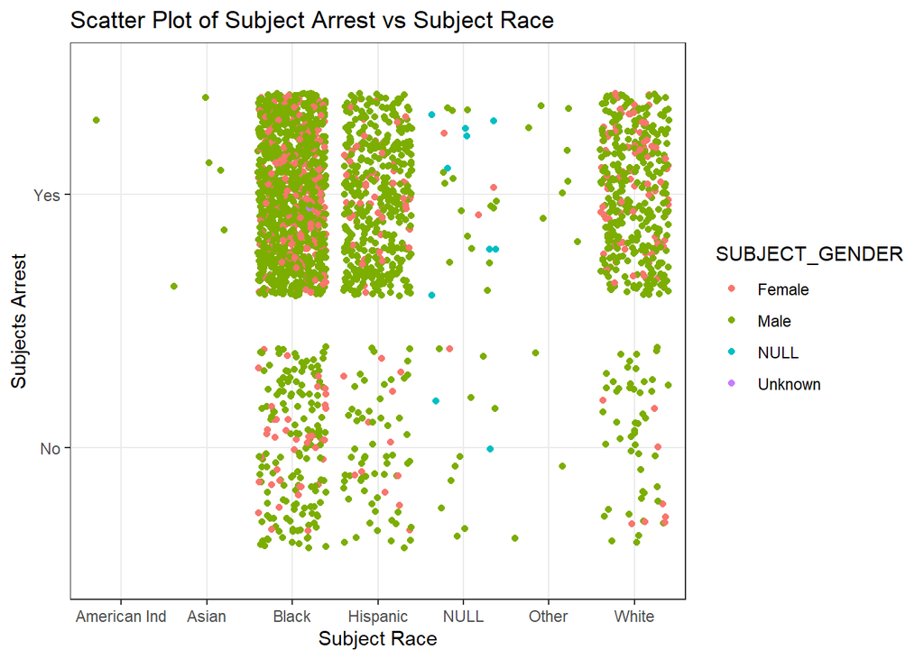

```r
#Creating Scatter Plot of Subject Race and officers Gender which is filled
ggplot(dallas,aes(SUBJECT_WAS_ARRESTED,SUBJECT_RACE,color=SUBJECT_GENDER))+
 geom_jitter(alpha=1.6)+coord_flip()+theme_bw()+labs(x="Subjects Arrest",y="Subject Race",title = "Scatter Plot of Subject Arrest vs Subject Race")
```

### Correlation Matrix

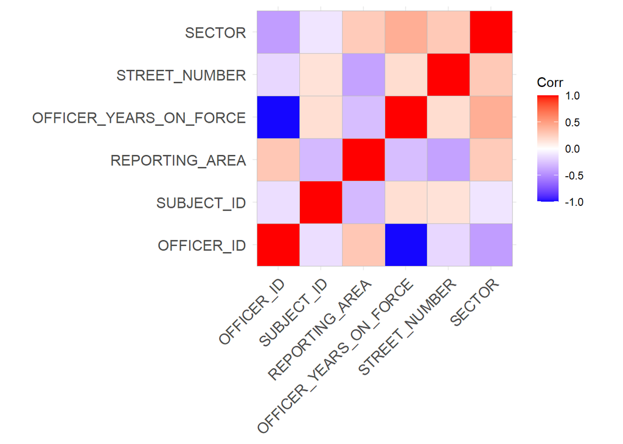

```r
set.seed(1201)
sampleDataSet <- dallas[sample(nrow(dallas), 15), ]
# Convert relevant columns to numeric
sampleDataSet$OFFICER_ID <- as.numeric(sampleDataSet$OFFICER_ID)
sampleDataSet$SUBJECT_ID <- as.numeric(sampleDataSet$SUBJECT_ID)
sampleDataSet$REPORTING_AREA <- as.numeric(sampleDataSet$REPORTING_AREA)
sampleDataSet$OFFICER_YEARS_ON_FORCE <- as.numeric(sampleDataSet$OFFICER_YEARS_ON_FORCE)
sampleDataSet$STREET_NUMBER <- as.numeric(sampleDataSet$STREET_NUMBER)
sampleDataSet$SECTOR <- as.numeric(sampleDataSet$SECTOR)

# Calculate correlation matrix
correlation_matrix <- cor(sampleDataSet[, c("OFFICER_ID","SUBJECT_ID" ,"REPORTING_AREA", "OFFICER_YEARS_ON_FORCE","STREET_NUMBER", "SECTOR")])
pval.cor <- cor_pmat(correlation_matrix)
require(ggplot2); require(ggcorrplot);
(G1 = ggcorrplot(correlation_matrix))
```

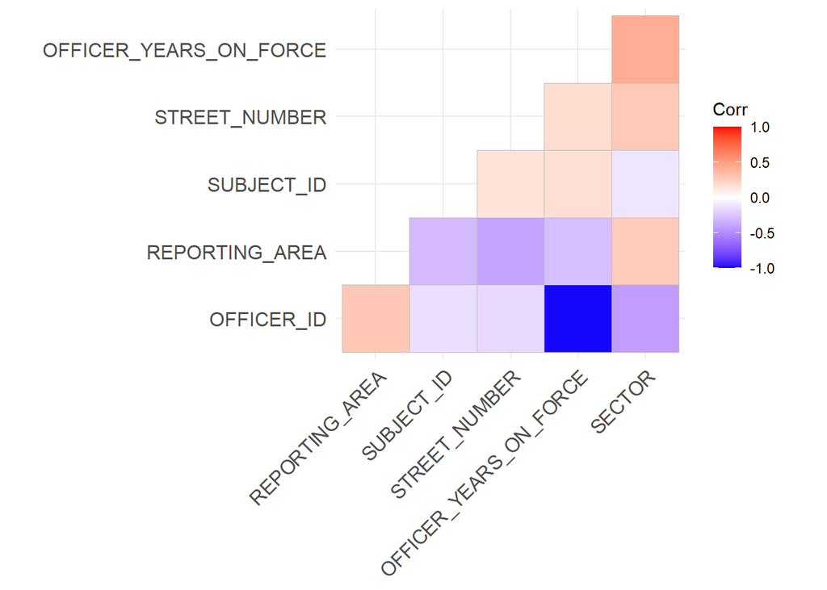

```r
(G2 = ggcorrplot(correlation_matrix, hc.order = TRUE, type = "lower"))
```

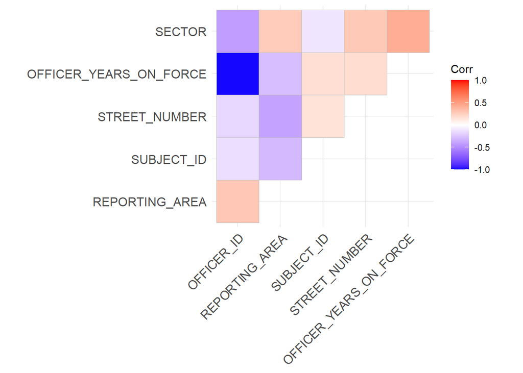

```r
(G3 = ggcorrplot(correlation_matrix, hc.order = TRUE, type = "upper"))
```

### Pie Chart Of Division and Officers Gender

#### The Central Division, followed by the North Central, North East, North West, South Central, South Central, South East, and South West divisions, is where the majority of the officers are from, as seen in the pie chart below.The second pie chart additionally shows the correlation between Division and Subject Race, showing that the Central Division, which is followed by the North Central, North East, North West, South Central, South Central, South East, and South West divisions, constitutes the majority of the subjects.

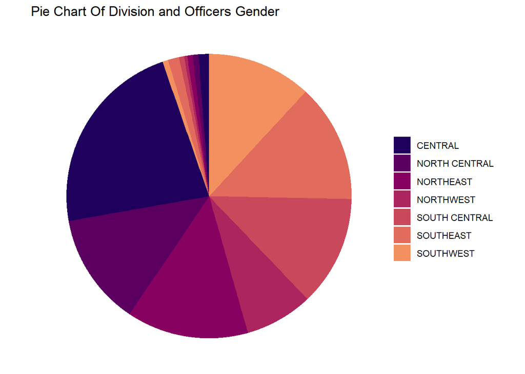

[figure not shown]

```r
ggplot(dallas, aes(x = "", y =OFFICER_GENDER, fill =DIVISION))+
 geom_bar(width = 1, stat = "identity")+coord_polar("y", start = 0)+ theme_void()+theme(legend.title = element_blank())+labs(title = "Pie Chart Of Division and Officers Gender")+scale_fill_manual(values = c("#1f005c", "#5b0060", "#870160", "#ac255e", "#ca485c", "#e16b5c","#f39060", "#ffb56b"))
```

### Table which shows the data of Type of Force Used

```r
library(formattable)
#In this line of code made a table in which we have taken the TYPE OF FORCED USED AND REASONFOR FORCE, So that we can understand the reason why the officer used force to arrest them.
dallas %>%
 table1(head(TYPE_OF_FORCE_USED1),n=10)%>%
 kbl() %>%
 kable_material_dark(head(c("striped", "hover")))
```

| . | Mean.Count..SD… |
| --- | --- |
|  | n = 6 |
| head(TYPE_OF_FORCE_USED1) |  |
| Hand Controlled Escort | 1 (16.7%) |
| Hand/Arm/Elbow Strike | 1 (16.7%) |
| Joint Locks | 1 (16.7%) |
| K-9 Deployment | 1 (16.7%) |
| Take Down - Group | 1 (16.7%) |
| Verbal Command | 1 (16.7%) |
| n |  |
|  | 10.0 (0.0) |

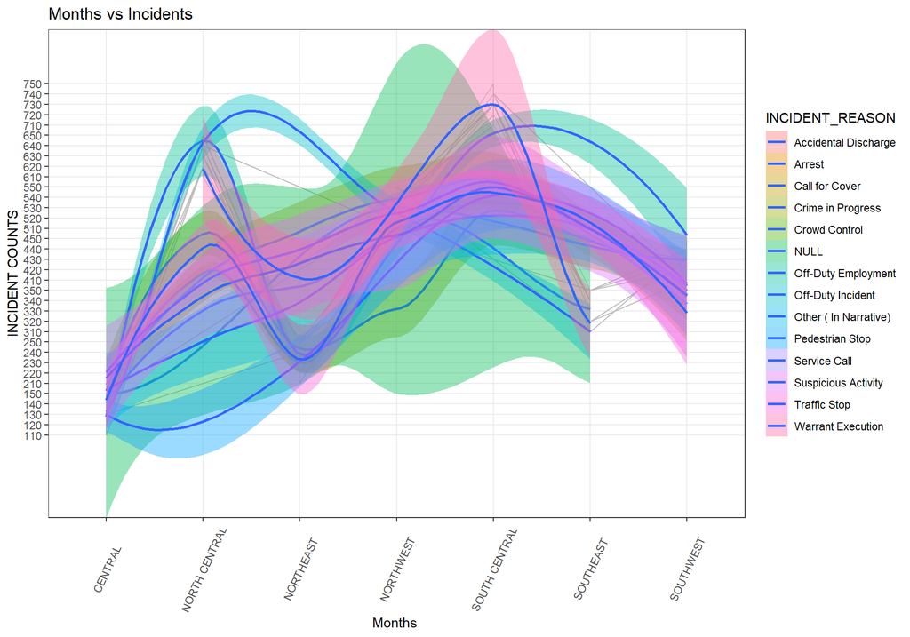

```r
ggplot(dallas, aes(DIVISION, SECTOR,group=INCIDENT_REASON,fill=INCIDENT_REASON)) +   geom_line(size=0.5, col="gray") +
geom_smooth(method = "loess") + theme_bw() + labs(x="Months ", y= "INCIDENT COUNTS", title="Months vs Incidents")+theme(axis.text.x = element_text(angle = 65,vjust=0.5))
```

### Time Series between Months vs Incident Rates

#### The time series plot shows that the month of March saw the most events, followed by the month of February.

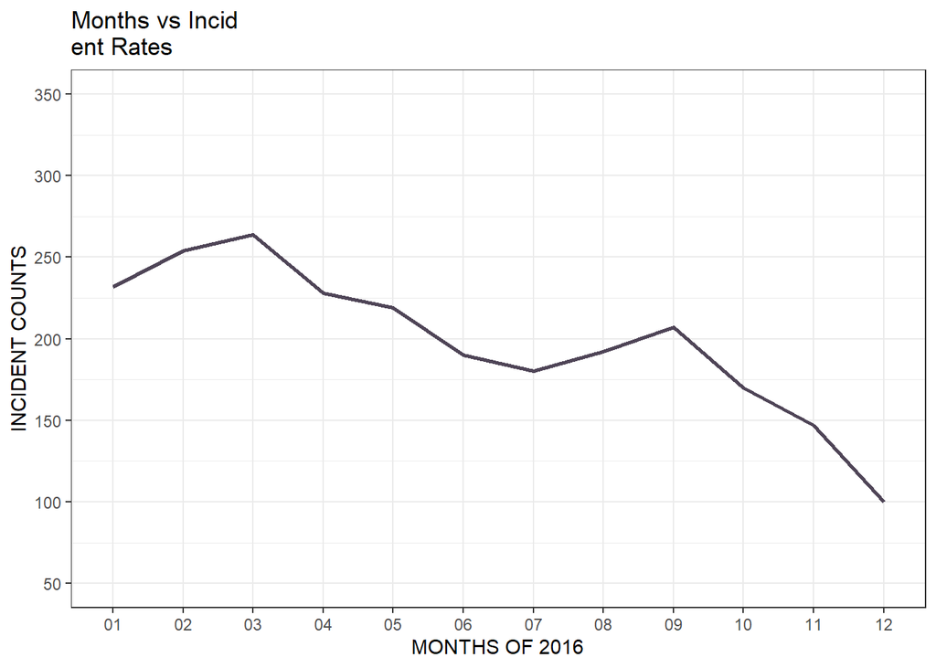

```r
dallasMonth <- dallas %>%
 group_by(INCI_MONTH) %>%
 summarize(count = n())

ggplot(dallasMonth, aes(x=INCI_MONTH, y =count, group=1)) + geom_line( size = 1,colour ="#4F4557") + labs(x="MONTHS OF 2016", y= "INCIDENT COUNTS", title="Months vs Incid
ent Rates") + theme_bw()+ scale_y_continuous(limits = c(50, 350), breaks = seq(0, 500, 50))
```

### Conclusion

#### This report’s objective is to investigate the patterns and behaviour of police in Dallas, Texas, in 2016. The survey did reveal that black people were detained more frequently than other ethnic groups, but it’s crucial to emphasize that the reasons why this is the case were not examined. To completely comprehend the difference that exists, more research will be required

#### References

##### 1.https://www.kaggle.com/center-for-policing-equity/data-science-for-good

##### 2.https://www.w3schools.com/

##### 3.https://stackoverflow.com/

##### 4.https://r-graph-gallery.com/

##### 5.https://www.geeksforgeeks.org